# Pacote MVN

Camila Simões, Jessyka Goltara, Leonardo Filgueira

2018-08-30

O pacote `MVN` está disponível no cran, e tem como objetivo analisar normalidade multivariada. Utilizaremos o dataset `iris` para os exemplos.

```r
require(MVN)
require(dplyr)

virginica <- iris %>%
  filter(Species == "virginica") %>%
  select(-Species)
```

A função `mvn` realiza testes de normalidade multivariada, gráficos multivariados, detecção de outliers multivariados, além de teste de normalidade e gráficos univariados.

## Testes de normalidade multivariada

Com o argumento `mvnTest` permite que escolhamos dentre 5 opções de testes:

- `mvnTest = "mardia"`: Ao utilizar esse valor, a função irá calcular o coeficiente de assimetria e de curtose de *Mardia*, assim como o p-valor associado às duas medidas.

  ```r
  resultado <- mvn(data = virginica, mvnTest = "mardia")
  DT::datatable(resultado$multivariateNormality, rownames = F)
  ```

  | Test | Statistic | p value | Result |
  | --- | --- | --- | --- |
  | Mardia Skewness | 26.2705981752915 | 0.157059707690356 | YES |
  | Mardia Kurtosis | 0.152614173978342 | 0.878702546726567 | YES |
  | MVN |  |  | YES |

  Se o resultado for positivo para o teste de curtose e assimetria, podemos supor que os dados são uma amostra de uma distribuição normal multivariada. Ou seja, este teste verifica a normalidade de acordo com essas duas características da distribuição: curtose e assimetria.
- `mvnTest = "hz"`: Desta maneira a função irá executar o teste de normalidade multivariada de *Henze-Zirkler*. A ideia basea-se na distância de *Mahalanobis* entre cada ponto e o centróide da distribuição, seguindo a ideia de medir a quantos desvios está uma observação da média.

  ```r
  resultado <- mvn(data = virginica, mvnTest = "hz")
  DT::datatable(resultado$multivariateNormality, rownames = F)
  ```

  | Test | HZ | p value | MVN |
  | --- | --- | --- | --- |
  | Henze-Zirkler | 0.757009524336352 | 0.497023692215559 | YES |

  Novamente temos a não rejeição da hipótese de normalidade multivariada.
- `mvnTest = "royston"`: O teste realizado neste caso é o teste de *Royston* é a generaliação do teste de Shapiro-Wilk para o caso multivariado.

  ```r
  resultado <- mvn(data = virginica, mvnTest = "royston")
  DT::datatable(resultado$multivariateNormality, rownames = F)
  ```

  | Test | H | p value | MVN |
  | --- | --- | --- | --- |
  | Royston | 8.14144387859746 | 0.0677660494481236 | YES |

  Novamente podemos dizer que temos uma amostra de uma distribuição normal multivariada.

  **Obs.:** Esse teste não poder ser aplicado para um $n > 5000$ ou $n < 3$. Essa condição é herdada do teste de Shapiro.
- `mvnTest = "dh"`: Ao escolher `dh` para este parâmetro, será realizado o teste de *Doornik-Hansen*, que, assim como o de Mardia, se baseia na assimetria e na curtose.

  ```r
  resultado <- mvn(data = virginica, mvnTest = "dh")
  DT::datatable(resultado$multivariateNormality, rownames = F)
  ```

  | Test | E | df | p value | MVN |
  | --- | --- | --- | --- | --- |
  | Doornik-Hansen | 24.3933750151481 | 8 | 0.00196824163343792 | NO |

  Perceba que este teste nos leva a rejeitar a hipótese de normalidade multivariada.

A função `mvn` possui um parâmetro `alpha`, que é o nível de singificância a ser usado nos testes, e por isso a função já retorna a decisão do teste: *YES* caso p-valor seja maior que `alpha` e *NO*, caso contrário.

- `mvnTest = "energy"`: Por fim, com este parâmetro será executado o teste baseado na *“Distância de energia”* [^1], que é uma distância entre distribuições de probabilidade.

  ```r
  resultado <- mvn(data = virginica, mvnTest = "energy")
  DT::datatable(resultado$multivariateNormality, rownames = F)
  ```

  | Test | Statistic | p value | MVN |
  | --- | --- | --- | --- |
  | E-statistic | 1.02185208447767 | 0.346 | YES |

  Segundo este teste não rejeitamos a hipótese de normalidade multivariada.

## Gráficos univariados

Com o parâmetro `univariatePlot` podemos escolher dentre Q-Q plots, histogramas, box plots ou gráficos de dispersão, um para cada variável. Certamente os dois primeiros facilitam mais na identificação da distribuição. Vejamos um exemplo com histograma:

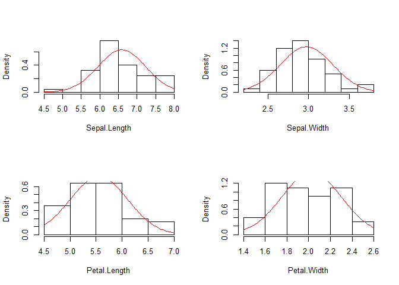

```r
histograma <- mvn(data = virginica, univariatePlot = "histogram")
```

Além dos gráficos, a função retorna alguns testes e estatísticas descritivas, de acordo com o parâmetro `mvnTest`. Podemos ver que a variável `Sepal.Width` é a que mais se aproxima da curva da distribuição normal.

## Testes univariados

Com o parâmetro `univariateTest`, podemos escolher dentre os testes de Shapiro-Wilk, *Cramer-von Mises*, *Lilliefors*, *Shapiro-Francia* ou *Anderson-Darling*, para ser aplicado a todas as variáveis do dataset.

## Gráficos bivariados

A função também permite que façamos gráficos bivariados, de perspectiva ou de contorno. Para isso então, selecionaremos apenas as duas primeiras colunas de `virginica`

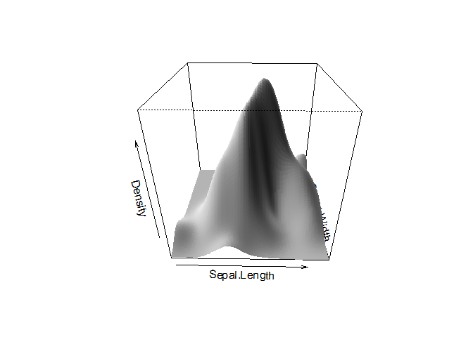

```r
virginica2 <- virginica[, 1:2]

perspectiva <- mvn(virginica2, multivariatePlot = "persp")
```

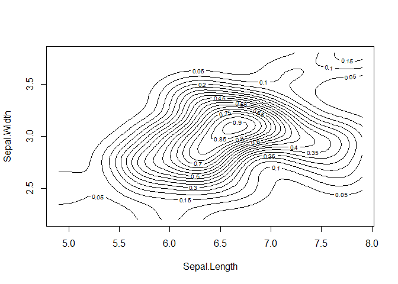

```r
contorno <- mvn(virginica2, multivariatePlot = "contour")
```

Novamente, além do gráfico são realizados os testes, de acordo com os parâmetros `mvnTest` e `univariateTest`.

## Outliers

Para a identificação de outliers multivariados foram implementados métodos para encontrar valores dicrepantes, baseados na distância de Mahalanobis. O parâmetro a ser utilizado é `multivariateOutlierMethod`, que pode ser `"quan"` ou `"adj"`, sendo o segundo a distância de Mahalanobis ajustada.

```r
out1 <- mvn(virginica, multivariateOutlierMethod = "quan")
```

[figure not shown]

```r
out2 <- mvn(virginica, multivariateOutlierMethod = "adj")
```

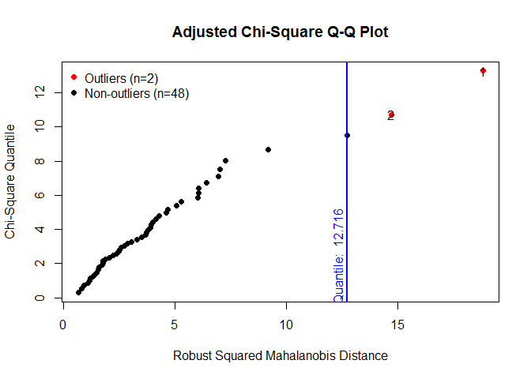

## Análise por grupos

A função `mvn` oferece a possibilidade de fazer a análise de normalidade por grupos. Basta utilizar o parâmetro `subset`, com o nome da coluna que apresenta os grupos entre aspas. Então vamos fazer a análise de normalidade por espécie.

```r
result <- mvn(data = iris, subset = "Species", mvnTest = "hz")

result$multivariateNormality
```

```
$setosa
           Test        HZ    p value MVN
1 Henze-Zirkler 0.9488453 0.04995356  NO

$versicolor
           Test        HZ   p value MVN
1 Henze-Zirkler 0.8388009 0.2261991 YES

$virginica
           Test        HZ   p value MVN
1 Henze-Zirkler 0.7570095 0.4970237 YES
```

Perceba que para cada espécie foi verificada a hipótese de normalidade. [^1]: A vignette do pacote apresenta um erro de digitação neste parâmetro, repetindo a mesma descrição do tópico anterior.

## Fontes:

- [vignette do pacote](https://cran.r-project.org/web/packages/MVN/vignettes/MVN.pdf)
- [help da função MVN](https://www.rdocumentation.org/packages/MVN/versions/5.5/topics/mvn)
- [Post sobre teste de normalidade multivariada no RPubs](http://rstudio-pubs-static.s3.amazonaws.com/356739_a9ed8f3ccc9045bf937b35a7d6379f6b.html)